# Analysing Sentences Backbone Communities

| First Author | Year | Journal | Citation by article | Citation by sentence |
| --- | --- | --- | --- | --- |
| SELTEN-R | 1975 | INT J GAME THEORY | 1 | 34 |
| AUMANN-R | 1976 | ANN STATISTICS | 1 | 34 |
| KOHLBERG-E | 1986 | ECONOMETRICA | 1 | 34 |
| AUMANN-R | 1974 | J MATH EC | 1 | 34 |
| GEANAKOPLOS-J | 1982 | J EC THEORY | 1 | 34 |
| FUDENBERG-D | 1993 | ECONOMETRICA | 1 | 34 |
| HAHN-F | 1977 | SCANDINAVIAN J EC | 1 | 34 |
| ROTHSCHILD-M | 1974 | J ECON THEORY | 1 | 34 |
| FUDENBERG-D | 1988 | J ECON THEORY | 1 | 34 |
| MYERSON-R | 1986 | ECONOMETRICA | 1 | 34 |

| First Author | Year | Journal | Citation by article | Citation by sentence |
| --- | --- | --- | --- | --- |
| FUDENBERG-D | 1991 | GAME THEORY | 48 | 1632 |
| FUDENBERG-D | 1988 | UNPUB THEORY LEARNIN | 23 | 782 |
| KREPS-D | 1990 | COURSE MICROECONOMIC | 21 | 714 |
| SCHELLING-T | 1960 | STRATEGY CONFLICT | 20 | 400 |
| HARSANYI-J | 1988 | GENERAL THEORY EQUIL | 33 | 297 |
| FREIDLIN-M | 1984 | RANDOM PERTURBATIONS | 10 | 200 |

| First Author | Year | Journal | Citation by article | Citation by sentence |
| --- | --- | --- | --- | --- |
| KREPS-D | 1982 | ECONOMETRICA | 1 | 71 |
| KREPS-D | 1982 | J EC THEORY | 1 | 71 |
| SELTEN-R | 1978 | THEORY DECISION | 1 | 71 |
| RENY-P | 1992 | J ECON PERSPECT | 1 | 71 |
| BERNHEIM-B | 1984 | ECONOMETRICA | 1 | 71 |
| PEARCE-D | 1984 | ECONOMETRICA | 1 | 71 |
| TAN-T | 1988 | J ECON THEORY | 1 | 71 |
| BINMORE-K | 1987 | EC PHILOS | 1 | 71 |
| AUMANN-R | 1987 | ECONOMETRICA | 1 | 71 |
| BASU-K | 1990 | INT J GAME THEORY | 1 | 71 |

| First Author | Year | Journal | Citation by article | Citation by sentence |
| --- | --- | --- | --- | --- |
| FUDENBERG-D | 1991 | GAME THEORY | 43 | 2193 |
| SCHELLING-T | 1960 | STRATEGY CONFLICT | 36 | 1728 |
| HARSANYI-J | 1988 | GEN THEORY EQUILIBRI | 33 | 1683 |
| SAVAGE-L | 1954 | FDN STAT | 18 | 1278 |
| AXELROD-R | 1984 | EVOLUTION COOPERATIO | 23 | 1173 |
| FRANK-R | 1988 | PASSIONS REASON | 13 | 624 |
| KEYNES-J | 1936 | GENERAL THEORY EMPLO | 13 | 624 |
| VONNEUMANN-J | 1947 | THEORY GAMES EC BEHA | 13 | 624 |
| LEWIS-D | 1969 | CONVENTION PHILOS ST | 12 | 576 |
| LUCE-R | 1957 | GAMES DECISIONS | 25 | 500 |

| First Author | Year | Journal | Citation by article | Citation by sentence |
| --- | --- | --- | --- | --- |
| EINHORN-H | 1978 | PSYCHOL REV | 1 | 62 |
| FISCHHOFF-B | 1977 | J EXPT PSYCHOL HUMAN | 1 | 62 |
| RESNIK-J | 1982 | HARVARD LAW REV | 1 | 62 |
| LORD-C | 1979 | J PERS SOC PSYCHOL | 1 | 62 |
| DARLEY-J | 1983 | J PERS SOC PSYCHOL | 1 | 62 |
| ROSS-L | 1987 | DISTINCTIVE APPROACH | 1 | 62 |
| CHAPMAN-L | 1969 | J ABNORM PSYCHOL | 1 | 62 |
| JENNINGS-D | 1982 | JUDGMENT UNCERTAINTY | 1 | 62 |
| KLAYMAN-J | 1987 | PSYCHOL REV | 1 | 62 |
| ZUCKERMAN-M | 1995 | J PERS SOC PSYCHOL | 1 | 62 |

| First Author | Year | Journal | Citation by article | Citation by sentence |
| --- | --- | --- | --- | --- |
| DEBREU-G | 1959 | THEORY VALUE | 30 | 1110 |
| FUDENBERG-D | 1991 | GAME THEORY | 51 | 1071 |
| SAVAGE-L | 1954 | FDN STAT | 43 | 989 |
| WILLIAMSON-O | 1975 | MARKETS HIERARCHIES | 66 | 924 |
| WILLIAMSON-O | 1985 | EC I CAPITALISM FIRM | 99 | 891 |
| LAFFONT-J | 1993 | THEORY INCENTIVES PR | 41 | 533 |
| NELSON-R | 1982 | EVOLUTIONARY THEORY | 32 | 480 |
| DEGROOT-M | 1970 | OPTIMAL STAT DECISIO | 15 | 480 |

| First Author | Year | Journal | Citation by article | Citation by sentence |
| --- | --- | --- | --- | --- |
| MCKELVEY-R | 1995 | GAME ECON BEHAV | 9 | 36 |
| CHO-I | 1987 | Q J EC | 29 | 29 |
| CRAWFORD-V | 1982 | ECONOMETRICA | 26 | 26 |
| HOTELLING-H | 1929 | EC J | 25 | 25 |
| ROTH-A | 1995 | GAME ECON BEHAV | 23 | 23 |
| FEHR-E | 1999 | Q J ECON | 23 | 23 |
| DASPREMONT-C | 1979 | ECONOMETRICA | 22 | 22 |
| GROSSMAN-S | 1986 | J POLIT EC | 20 | 20 |
| RUBINSTEIN-A | 1982 | ECONOMETRICA | 20 | 20 |
| SELTEN-R | 1975 | INT J GAME THEORY | 10 | 20 |

| First Author | Year | Journal | Citation by article | Citation by sentence |
| --- | --- | --- | --- | --- |
| SCHELLING-T | 1960 | STRATEGY CONFLICT | 40 | 360 |
| FUDENBERG-D | 1991 | GAME THEORY | 65 | 325 |
| VIVES-X | 1999 | OLIGOPOLY PRICING OL | 35 | 280 |
| OSBORNE-M | 1994 | COURSE GAME THEORY | 23 | 276 |
| CAMERER-C | 2003 | BEHAV GAME THEORY | 24 | 264 |
| OLSON-M | 1965 | LOGIC COLLECTIVE ACT | 24 | 216 |
| WEIBULL-J | 1995 | EVOLUTIONARY GAME TH | 19 | 209 |
| VONNEUMANN-J | 1944 | THEORY GAMES EC BEHA | 18 | 198 |

| First Author | Year | Journal | Citation by article | Citation by sentence |
| --- | --- | --- | --- | --- |
| GUL-F | 1986 | J EC THEORY | 2 | 122 |
| KREPS-D | 1982 | J EC THEORY | 2 | 122 |
| MILGROM-P | 1982 | J EC THEORY | 2 | 122 |
| SCHMIDT-K | 1993 | ECONOMETRICA | 2 | 122 |
| CRAMTON-P | 1984 | REV ECON STUD | 1 | 61 |
| GUL-F | 1988 | ECONOMETRICA | 1 | 61 |
| SOBEL-J | 1983 | REV ECON STUD | 1 | 61 |
| CHATTERJEE-K | 1988 | OPER RES | 1 | 61 |
| CHATTERJEE-K | 1987 | REV ECON STUD | 1 | 61 |
| GROSSMAN-S | 1986 | JET | 1 | 61 |

| First Author | Year | Journal | Citation by article | Citation by sentence |
| --- | --- | --- | --- | --- |
| FUDENBERG-D | 1998 | THEORY LEARNING GAME | 67 | 3886 |
| HARSANYI-J | 1988 | GEN THEORY EQUILIBRI | 62 | 3596 |
| WEIBULL-J | 1995 | EVOLUTIONARY GAME TH | 46 | 2668 |
| VONNEUMANN-J | 1944 | THEORY GAMES EC BEHA | 39 | 1833 |
| SAMUELSON-L | 1997 | EVOLUTIONARY GAMES E | 30 | 1740 |
| SCHELLING-T | 1960 | STRATEGY CONFLICT | 43 | 1462 |
| CAMERER-C | 2003 | BEHAV GAME THEORY EX | 85 | 1445 |
| MYERSON-R | 1991 | GAME THEORY ANAL CON | 19 | 1159 |

| First Author | Year | Journal | Citation by article | Citation by sentence |
| --- | --- | --- | --- | --- |
| HOLMSTROM-B | 1991 | J LAW ECON ORGAN | 50 | 50 |
| HOLMSTROM-B | 1979 | BELL J EC | 20 | 40 |
| HOLMSTROM-B | 1979 | BELL J EC | 39 | 39 |
| HOLMSTROM-B | 1982 | BELL J EC | 38 | 38 |
| HOLMSTROM-B | 1991 | J LAW ECON ORGAN | 9 | 36 |
| AKERLOF-G | 1970 | Q J EC | 1 | 34 |
| GUL-F | 1992 | ECONOMETRICA | 1 | 34 |
| POSTLEWAITE-A | 1986 | J EC THEORY | 1 | 34 |
| AUMANN-R | 1964 | ECONOMETRICA | 1 | 34 |
| PRESCOTT-E | 1984 | ECONOMETRICA | 1 | 34 |

| First Author | Year | Journal | Citation by article | Citation by sentence |
| --- | --- | --- | --- | --- |
| LAFFONT-J | 1993 | THEORY INCENTIVES PR | 76 | 1064 |
| FUDENBERG-D | 1991 | GAME THEORY | 40 | 600 |
| LAFFONT-J | 2002 | THEORY INCENTIVES PR | 39 | 585 |
| GREEN-J | 1979 | INCENTIVES PUBLIC DE | 15 | 510 |
| WILLIAMSON-O | 1985 | EC I CAPITALISM FIRM | 65 | 455 |
| MYERSON-R | 1991 | GAME THEORY ANAL CON | 13 | 442 |
| MILGROM-P | 1992 | EC ORG MANAGEMENT | 26 | 442 |
| BOLTON-P | 2005 | CONTRACT THEORY | 15 | 390 |

| First Author | Year | Journal | Citation by article | Citation by sentence |
| --- | --- | --- | --- | --- |
| BIKHCHANDANI-S | 1992 | J POLIT ECON | 5 | 30 |
| AGHION-P | 1997 | J POLITICAL EC | 30 | 30 |
| BIKHCHANDANI-S | 1992 | J POLIT ECON | 7 | 28 |
| DANIEL-K | 1998 | J FINANC | 2 | 26 |
| TVERSKY-A | 1973 | COGNITIVE PSYCHOLOGY | 1 | 25 |
| BANERJEE-A | 1992 | Q J ECON | 1 | 25 |
| BIKHCHANDANI-S | 1992 | J POLIT ECON | 1 | 25 |
| GILBERT-D | 1991 | AM PSYCHOL | 1 | 25 |
| EVANS-W | 1992 | J POLIT ECON | 1 | 25 |
| FRENCH-J | 1956 | PSYCHOL REV | 1 | 25 |

| First Author | Year | Journal | Citation by article | Citation by sentence |
| --- | --- | --- | --- | --- |
| WOODFORD-M | 2003 | INTEREST PRICES | 34 | 476 |
| EVANS-G | 2001 | LEARNING EXPECTATION | 43 | 473 |
| SAVAGE-L | 1954 | FDN STAT | 30 | 450 |
| SARGENT-T | 1993 | BOUNDED RATIONALITY | 33 | 363 |
| FUDENBERG-D | 1991 | GAME THEORY | 31 | 310 |
| ALIPRANTIS-C | 1999 | INFINITE DIMENSIONAL | 23 | 299 |
| SARGENT-T | 1999 | CONQUEST AM INFLATIO | 26 | 286 |
| KURZ-M | 1997 | ENDOGENOUS EC FLUCTU | 18 | 270 |
| KNIGHT-F | 1921 | RISK UNCERTAINTY PRO | 27 | 270 |
| MASCOLELL-A | 1995 | MICROECONOMIC THEORY | 37 | 259 |

| First Author | Year | Journal | Citation by article | Citation by sentence |
| --- | --- | --- | --- | --- |
| FEDDERSEN-T | 1998 | AM POLIT SCI REV | 4 | 52 |
| BANKS-J | 1985 | SOC CHOICE WELFARE | 2 | 44 |
| SHEPSLE-K | 1984 | AM J POLIT SCI | 2 | 44 |
| ORDESHOOK-P | 1987 | AM POLIT SCI REV | 2 | 44 |
| AUSTENSMITH-D | 1987 | AM POLIT SCI REV | 2 | 44 |
| BARRO-R | 1973 | PUBLIC CHOICE | 6 | 42 |
| WITTMAN-D | 1989 | J POLIT ECON | 2 | 40 |
| ROGOFF-K | 1990 | AM ECON REV | 5 | 40 |
| GROSSMAN-G | 1994 | AM ECON REV | 1 | 40 |
| HOTELLING-H | 1929 | EC J | 2 | 40 |

| First Author | Year | Journal | Citation by article | Citation by sentence |
| --- | --- | --- | --- | --- |
| PERSSON-T | 2000 | POLITICAL EC | 132 | 3432 |
| DOWNS-A | 1957 | EC THEORY DEMOCRACY | 164 | 3280 |

| First Author | Year | Journal | Citation by article | Citation by sentence |
| --- | --- | --- | --- | --- |
| LUCAS-R | 1988 | J MONETARY ECON | 22 | 22 |
| CHO-I | 1987 | Q J EC | 21 | 21 |
| MARCET-A | 1989 | J ECON THEORY | 1 | 20 |
| KATZ-M | 1986 | J POLITICAL EC | 1 | 20 |
| COOPER-R | 1988 | Q J ECON | 1 | 20 |
| HOWITT-P | 1992 | AM ECON REV | 1 | 20 |
| DIAMOND-D | 1983 | J POLITICAL EC | 20 | 20 |
| KANDORI-M | 1993 | ECONOMETRICA | 1 | 20 |
| VANHUYCK-J | 1990 | AM ECON REV | 1 | 20 |
| WOODFORD-M | 1990 | ECONOMETRICA | 1 | 20 |

| First Author | Year | Journal | Citation by article | Citation by sentence |
| --- | --- | --- | --- | --- |
| FUDENBERG-D | 1991 | GAME THEORY | 38 | 494 |
| EVANS-G | 2001 | LEARNING EXPECTATION | 24 | 480 |
| HARSANYI-J | 1988 | GEN THEORY EQUILIBRI | 18 | 360 |
| SARGENT-T | 1999 | CONQUEST AM INFLATIO | 13 | 260 |
| WOODFORD-M | 2003 | INTEREST PRICES | 27 | 189 |
| COOPER-R | 1999 | COORDINATION GAMES C | 9 | 180 |
| SARGENT-T | 1993 | BOUNDED RATIONALITY | 9 | 180 |
| YOUNG-H | 1998 | INDIVIDUAL STRATEGY | 8 | 160 |
| DEBREU-G | 1959 | THEORY VALUE | 32 | 128 |
| SCHELLING-T | 1960 | STRATEGY CONFLICT | 16 | 112 |

| First Author | Year | Journal | Citation by article | Citation by sentence |
| --- | --- | --- | --- | --- |
| MILGROM-P | 1982 | ECONOMETRICA | 15 | 90 |
| MYERSON-R | 1981 | MATH OPERATIONS RES | 15 | 60 |
| MYERSON-R | 1981 | MATH OPERATIONS RES | 10 | 60 |
| MILGROM-P | 1982 | ECONOMETRICA | 25 | 50 |
| MILGROM-P | 1982 | ECONOMETRICA | 5 | 50 |
| MILGROM-P | 1982 | ECONOMETRICA | 16 | 48 |
| MILGROM-P | 1982 | ECONOMETRICA | 6 | 48 |
| MILGROM-P | 1982 | ECONOMETRICA | 9 | 45 |
| MYERSON-R | 1981 | MATH OPERATIONS RES | 14 | 42 |
| MILGROM-P | 1982 | ECONOMETRICA | 1 | 41 |

| First Author | Year | Journal | Citation by article | Citation by sentence |
| --- | --- | --- | --- | --- |
| FUDENBERG-D | 1991 | GAME THEORY | 30 | 690 |
| WILLIAMSON-O | 1985 | EC I CAPITALISM FIRM | 25 | 575 |
| KRISHNA-V | 2002 | AUCTION THEORY | 56 | 560 |
| WILLIAMSON-O | 1975 | MARKETS HIERARCHIES | 15 | 405 |
| TIROLE-J | 1988 | THEORY IND ORG | 41 | 369 |
| KAGEL-J | 2002 | COMMON VALUE AUCTION | 14 | 364 |

| First Author | Year | Journal | Citation by article | Citation by sentence |
| --- | --- | --- | --- | --- |
| FEHR-E | 1999 | Q J ECON | 12 | 48 |
| RUBINSTEIN-A | 1982 | ECONOMETRICA | 11 | 44 |
| RUBINSTEIN-A | 1982 | ECONOMETRICA | 41 | 41 |
| RABIN-M | 1993 | AM ECON REV | 10 | 40 |
| FORSYTHE-R | 1994 | GAMES EC BEHAVIOR | 5 | 40 |
| HOFFMAN-E | 1994 | GAMES EC BEHAVIOR | 5 | 40 |
| FEHR-E | 1999 | Q J ECON | 20 | 40 |
| BOLTON-G | 2000 | AM ECON REV | 10 | 40 |
| RUBINSTEIN-A | 1982 | ECONOMETRICA | 13 | 39 |
| FEHR-E | 1999 | Q J ECON | 39 | 39 |

| First Author | Year | Journal | Citation by article | Citation by sentence |
| --- | --- | --- | --- | --- |
| OSBORNE-M | 1990 | BARGAINING MARKETS | 56 | 1232 |
| SCHELLING-T | 1960 | STRATEGY CONFLICT | 40 | 1160 |
| CAMERER-C | 2003 | BEHAV GAME THEORY EX | 54 | 1134 |
| ROTH-A | 1995 | HDB EXPT EC | 20 | 540 |
| FUDENBERG-D | 1991 | GAME THEORY | 18 | 486 |
| WEIBULL-J | 1995 | EVOLUTIONARY GAME TH | 16 | 464 |
| STAHL-I | 1972 | BARGAINING THEORY | 12 | 324 |

## Intertemporal cluster *2: mill’s, malthus, adam_smith, adam*

The cluster gathers 14781 sentences from our corpus. It represents 5.45% of all the sentences selected over the whole period.

The community exists from 1900 to 2009.

The most recurring authors are Zafirovski M. (172 sentences; 5 articles), Frank H. Knight (92 sentences; 41 articles), Jr. (75 sentences; 54 articles), Hosseini H. (72 sentences; 4 articles), Jacob Viner (68 sentences; 16 articles), Talcott Parsons (65 sentences; 11 articles), Joseph J. Spengler (65 sentences; 18 articles), O. H. Taylor (56 sentences; 8 articles), Berg N. (53 sentences; 4 articles), William D. Grampp (52 sentences; 9 articles), Rabin M. (50 sentences; 1 articles), Ronald L. Meek (49 sentences; 10 articles), Jacob H. Hollander (43 sentences; 11 articles), Lea S. (43 sentences; 1 articles), Paul T. Homan (42 sentences; 10 articles).

The most recurring journals are Journal of Socio Economics (1045 sentences; 240 articles), The American Economic Review (935 sentences; 590 articles), Journal of Political Economy (907 sentences; 379 articles), The Quarterly Journal of Economics (742 sentences; 339 articles), The Economic Journal (573 sentences; 342 articles), Ecological Economics (554 sentences; 271 articles).

### Top TF-IDF terms describing the community

| Token | TF-IDF |
| --- | --- |
| mill’s | 0.0118752 |
| malthus | 0.0095726 |
| adam_smith | 0.0061740 |
| adam | 0.0054251 |
| mill | 0.0045325 |
| smith’s | 0.0044581 |
| adam_smith’s | 0.0042287 |
| smith | 0.0039209 |
| john_stuart | 0.0038320 |
| stuart_mill | 0.0035372 |
| ricardo | 0.0035114 |
| hours | 0.0033125 |
| neoclassical | 0.0032990 |
| stuart | 0.0032184 |
| nations | 0.0027841 |
| behavioral_economics | 0.0027526 |
| neoclassical_economics | 0.0024632 |
| ricardo’s | 0.0022806 |
| sentiments | 0.0022683 |
| employees | 0.0021384 |

### Top TF-IDF terms describing the different k-means clusters

#### Top terms 2_12_1900-1919: workman, workmen, hours, employers, employer (1900-1919)

| Token | TF-IDF |
| --- | --- |
| workman | 0.0135236 |
| workmen | 0.0124685 |
| hours | 0.0098229 |
| employers | 0.0081348 |
| employer | 0.0081348 |
| wages | 0.0063174 |
| laborer | 0.0060459 |
| labor | 0.0052319 |
| union | 0.0052204 |
| labour | 0.0029822 |
| physiological | 0.0028561 |
| women | 0.0027116 |
| compel | 0.0024948 |
| unions | 0.0024173 |
| hour | 0.0023670 |

#### Top terms 2_7_1900-1919: mill, mill’s, john_stuart, stuart_mill, stuart (1900-1919)

| Token | TF-IDF |
| --- | --- |
| mill | 0.0331479 |
| mill’s | 0.0324813 |
| john_stuart | 0.0131821 |
| stuart_mill | 0.0129003 |
| stuart | 0.0110361 |
| ricardo | 0.0073957 |
| sacrifice | 0.0053002 |
| political_economy | 0.0048153 |
| mankind | 0.0044861 |
| john | 0.0043682 |
| malthus | 0.0042410 |
| duties | 0.0036858 |
| successors | 0.0036090 |
| sympathy | 0.0030972 |
| classical_economics | 0.0028907 |

#### Top terms 2_11_1900-1919: political_economy, economic_science, marx, spiritual, science (1900-1919)

| Token | TF-IDF |
| --- | --- |
| political_economy | 0.0040774 |
| economic_science | 0.0037077 |
| marx | 0.0032825 |
| spiritual | 0.0032646 |
| science | 0.0031072 |
| truths | 0.0023425 |
| marxian | 0.0022233 |
| sober | 0.0022233 |
| economic_laws | 0.0021279 |
| economic_doctrine | 0.0020836 |
| socialist | 0.0020509 |
| economist | 0.0019520 |
| eighteenth_century | 0.0017881 |
| distinctly | 0.0016689 |
| economics | 0.0016354 |

#### Top terms 2_10_1900-1919: private_property, property, employees, laborer, institution (1900-1919)

| Token | TF-IDF |
| --- | --- |
| private_property | 0.0102513 |
| property | 0.0094584 |
| employees | 0.0061079 |
| laborer | 0.0058435 |
| institution | 0.0056240 |
| children | 0.0055294 |
| injustice | 0.0048822 |
| property_rights | 0.0048055 |
| ownership | 0.0043136 |
| rights | 0.0041591 |
| landlord | 0.0036807 |
| parents | 0.0036807 |
| morals | 0.0033302 |
| tenure | 0.0033302 |
| pains | 0.0032548 |

#### Top terms 2_6_1900-1919: adam_smith, adam, smith, smith’s, adam_smith’s (1900-1919)

| Token | TF-IDF |
| --- | --- |
| adam_smith | 0.0464546 |
| adam | 0.0430981 |
| smith | 0.0213276 |
| smith’s | 0.0192369 |
| adam_smith’s | 0.0175568 |
| ricardo | 0.0149393 |
| mercantile | 0.0052670 |
| nations | 0.0044599 |
| grew | 0.0039539 |
| free_trade | 0.0035903 |
| doctrines | 0.0034922 |
| physiocrats | 0.0034363 |
| enumerated | 0.0034363 |
| dissent | 0.0031681 |
| english | 0.0030620 |

#### Top terms 2_11_1920-1929: economic_life, economic_history, marx, capitalism, laws (1920-1929)

| Token | TF-IDF |
| --- | --- |
| economic_life | 0.0044119 |
| economic_history | 0.0040647 |
| marx | 0.0033415 |
| capitalism | 0.0031653 |
| laws | 0.0028065 |
| deductive | 0.0026035 |
| marxian | 0.0025865 |
| human_nature | 0.0024810 |
| science | 0.0024529 |
| economic_doctrine | 0.0024240 |
| economics | 0.0023936 |
| political_economy | 0.0022640 |
| marx’s | 0.0021364 |
| economist | 0.0020817 |
| tho | 0.0016792 |

#### Top terms 2_6_1920-1929: hours, worker, labor, wages, labour (1920-1929)

| Token | TF-IDF |
| --- | --- |
| hours | 0.0060962 |
| worker | 0.0046945 |
| labor | 0.0046841 |
| wages | 0.0044143 |
| labour | 0.0041677 |
| real_costs | 0.0037222 |
| workers | 0.0036467 |
| employer | 0.0035527 |
| grade | 0.0034667 |
| wealth | 0.0030641 |
| laborer | 0.0029704 |
| inheritance | 0.0024272 |
| pain | 0.0023753 |
| employee | 0.0023753 |
| wealthy | 0.0022786 |

#### Top terms 2_7_1920-1929: adam_smith, adam, smith, malthus, smith’s (1920-1929)

| Token | TF-IDF |
| --- | --- |
| adam_smith | 0.0173610 |
| adam | 0.0161973 |
| smith | 0.0133022 |
| malthus | 0.0106232 |
| smith’s | 0.0093524 |
| mill | 0.0091031 |
| moral_sentiments | 0.0090715 |
| nations | 0.0081311 |
| mill’s | 0.0077487 |
| adam_smith’s | 0.0067387 |
| ricardo | 0.0052929 |
| sentiments | 0.0050812 |
| john_stuart | 0.0040432 |
| stuart_mill | 0.0039568 |
| beneficent | 0.0037940 |

#### Top terms 2_12_1920-1929: religious, religion, moral_sentiments, nations, sentiments (1920-1929)

| Token | TF-IDF |
| --- | --- |
| religious | 0.0180737 |
| religion | 0.0160319 |
| moral_sentiments | 0.0133010 |
| nations | 0.0080526 |
| sentiments | 0.0074502 |
| seventeenth | 0.0066669 |
| medieval | 0.0064599 |
| spiritual | 0.0061192 |
| economic_transactions | 0.0059655 |
| moral | 0.0053336 |
| economic_life | 0.0052654 |
| secular | 0.0052080 |
| ethics | 0.0049010 |
| morality | 0.0043152 |
| economic_questions | 0.0041890 |

#### Top terms 2_13_1930-1939: mercantilist, marx, economics, eighteenth_century, science (1930-1939)

| Token | TF-IDF |
| --- | --- |
| mercantilist | 0.0027301 |
| marx | 0.0026127 |
| economics | 0.0020471 |
| eighteenth_century | 0.0019570 |
| science | 0.0018549 |
| economic_history | 0.0018540 |
| socialist | 0.0018365 |
| socialism | 0.0018278 |
| eighteenth | 0.0017669 |
| capitalism | 0.0017596 |
| economic_theory | 0.0017222 |
| marx’s | 0.0017053 |
| faire | 0.0014889 |
| orthodox_economics | 0.0014249 |
| secular | 0.0013995 |

#### Top terms 2_12_1930-1939: malthus, adam_smith, adam, mill’s, mill (1930-1939)

| Token | TF-IDF |
| --- | --- |
| malthus | 0.0203282 |
| adam_smith | 0.0107745 |
| adam | 0.0098919 |
| mill’s | 0.0092673 |
| mill | 0.0065982 |
| ricardo | 0.0063302 |
| smith | 0.0060699 |
| population | 0.0053926 |
| adam_smith’s | 0.0038684 |
| smith’s | 0.0037677 |
| malthusian | 0.0034812 |
| political_economy | 0.0032973 |
| john_stuart | 0.0032237 |
| physiocrats | 0.0031548 |
| stuart_mill | 0.0031548 |

#### Top terms 2_14_1940-1949: socialism, socialist, marx, faire, physiocrats (1940-1949)

| Token | TF-IDF |
| --- | --- |
| socialism | 0.0032171 |
| socialist | 0.0029293 |
| marx | 0.0025867 |
| faire | 0.0021441 |
| physiocrats | 0.0020961 |
| economic_science | 0.0020696 |
| free_enterprise | 0.0019843 |
| economist | 0.0019656 |
| laissez | 0.0018137 |
| laissez_faire | 0.0018137 |
| economic_principle | 0.0018036 |
| marx’s | 0.0017687 |
| science | 0.0017198 |
| capitalism | 0.0016081 |
| marxian | 0.0016060 |

#### Top terms 2_11_1940-1949: malthus, mill’s, smith’s, smith, mill (1940-1949)

| Token | TF-IDF |
| --- | --- |
| malthus | 0.0152165 |
| mill’s | 0.0135964 |
| smith’s | 0.0128322 |
| smith | 0.0108753 |
| mill | 0.0105103 |
| adam | 0.0103663 |
| adam_smith | 0.0094093 |
| moral_sentiments | 0.0082688 |
| adam_smith’s | 0.0067566 |
| sentiments | 0.0055579 |
| john_stuart | 0.0054053 |
| political_economy | 0.0051831 |
| stuart | 0.0045253 |
| stuart_mill | 0.0039673 |
| nations | 0.0034327 |

#### Top terms 2_12_1950-1959: soviet, economist, political_economy, economic_theory, natural_law (1950-1959)

| Token | TF-IDF |
| --- | --- |
| soviet | 0.0042500 |
| economist | 0.0021316 |
| political_economy | 0.0017184 |
| economic_theory | 0.0017040 |
| natural_law | 0.0016009 |
| marxian | 0.0015116 |
| economics | 0.0015065 |
| economic_analysis | 0.0014697 |
| marx | 0.0014203 |
| socialism | 0.0013879 |
| classical_economics | 0.0013410 |
| economists | 0.0011725 |
| economic_science | 0.0011459 |
| capitalism | 0.0010931 |
| capitalist | 0.0010693 |

#### Top terms 2_7_1950-1959: malthus, ricardo, adam_smith, mill, ricardo’s (1950-1959)

| Token | TF-IDF |
| --- | --- |
| malthus | 0.0238854 |
| ricardo | 0.0111072 |
| adam_smith | 0.0101279 |
| mill | 0.0086832 |
| ricardo’s | 0.0084847 |
| adam | 0.0083684 |
| mill’s | 0.0081304 |
| smith | 0.0080984 |
| john_stuart | 0.0066665 |
| stuart_mill | 0.0059309 |
| malthusian | 0.0057266 |
| stuart | 0.0055813 |
| smith’s | 0.0044270 |
| nations | 0.0042337 |
| parsimony | 0.0038500 |

#### Top terms 2_20_1960-1969: economic_theory, economic_analysis, economist, economic_development, economic_arguments (1960-1969)

| Token | TF-IDF |
| --- | --- |
| economic_theory | 0.0025088 |
| economic_analysis | 0.0021971 |
| economist | 0.0021825 |
| economic_development | 0.0018659 |
| economic_arguments | 0.0016943 |
| economists | 0.0016424 |
| economics | 0.0015765 |
| economic_history | 0.0014205 |
| deductive | 0.0014153 |
| economic_theorists | 0.0013958 |
| economic_phenomena | 0.0013570 |
| economic_grounds | 0.0011964 |
| professional | 0.0011398 |
| economic_factors | 0.0010126 |
| discipline | 0.0010110 |

#### Top terms 2_13_1970-1979: neoclassical, economist, economics, economic_theory, economists (1970-1979)

| Token | TF-IDF |
| --- | --- |
| neoclassical | 0.0043491 |
| economist | 0.0024228 |
| economics | 0.0022070 |
| economic_theory | 0.0021531 |
| economists | 0.0018594 |
| economic_analysis | 0.0017886 |
| model | 0.0016183 |
| neoclassical_theory | 0.0015840 |
| neoclassical_economics | 0.0014888 |
| models | 0.0014355 |
| positive_economics | 0.0014301 |
| mathematical_economics | 0.0012849 |
| economic_reasoning | 0.0011786 |
| economic_policy | 0.0011677 |
| conventional_economic | 0.0011544 |

#### Top terms 2_6_1980-1989: neoclassical, neoclassical_economics, physics, model, economics (1980-1989)

| Token | TF-IDF |
| --- | --- |
| neoclassical | 0.0068575 |
| neoclassical_economics | 0.0028170 |
| physics | 0.0024414 |
| model | 0.0023390 |
| economics | 0.0021244 |
| rationality | 0.0020656 |
| models | 0.0020167 |
| economic_theory | 0.0018347 |
| economists | 0.0017081 |
| neoclassical_theory | 0.0016906 |
| macroeconomic | 0.0016898 |
| economist | 0.0015820 |
| neoclassical_economic | 0.0015718 |
| economic_interpretation | 0.0013884 |
| macroeconomics | 0.0013525 |

#### Top terms 2_6_1990-1999: neoclassical, neoclassical_economics, rationality, economics, rational_choice (1990-1999)

| Token | TF-IDF |
| --- | --- |
| neoclassical | 0.0066632 |
| neoclassical_economics | 0.0044169 |
| rationality | 0.0032192 |
| economics | 0.0027617 |
| rational_choice | 0.0024493 |
| model | 0.0023058 |
| homo | 0.0022597 |
| sociology | 0.0022395 |
| economists | 0.0021690 |
| mainstream | 0.0021639 |
| choice_theory | 0.0020684 |
| models | 0.0019793 |
| economic_theory | 0.0018287 |
| economic_intuition | 0.0015272 |
| socio_economics | 0.0015247 |

#### Top terms 2_4_2000-2009: behavioral_economics, neoclassical, neoclassical_economics, economics, economic_intuition (2000-2009)

| Token | TF-IDF |
| --- | --- |
| behavioral_economics | 0.0048480 |
| neoclassical | 0.0045903 |
| neoclassical_economics | 0.0034787 |
| economics | 0.0029617 |
| economic_intuition | 0.0028977 |
| model | 0.0027872 |
| mainstream | 0.0027394 |
| behavioral | 0.0024359 |
| homo | 0.0024132 |
| models | 0.0024108 |
| rationality | 0.0021066 |
| homo_economicus | 0.0020057 |
| economicus | 0.0019307 |
| economic_theory | 0.0019124 |
| economic_models | 0.0017762 |

### Distribution of sentences over time

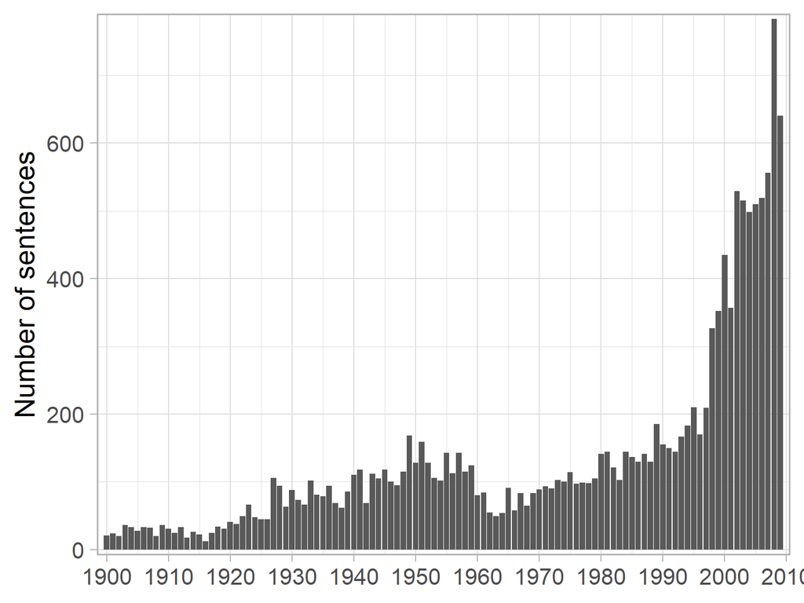

### Closest sentence from ‘rational’ and ‘rationality’ of the backbone community

| Sentence | Title | Year | Journal | Authors | Words Similarity |
| --- | --- | --- | --- | --- | --- |
| This concept was introduced by Simon [4], who states that the behavior of economic agents is “intendedly rational, but only limitedly so”. | Integration of production and logistics - in principle, in practice and in education | 2001 | International Journal of Production Economics | Chikán A. | 0.865 |
| Economic agents are assumed to be rational. | Exchange rate fluctuations and disaggregated economic activity in the US: Theory and evidence | 2002 | Journal of International Money and Finance | Kandil M. | 0.814 |
| Economic agents are assumed to be rational. | The effects of dollar appreciation on sectoral labor market adjustments: Theory and evidence | 2003 | Quarterly Review of Economics and Finance | Kandil M. | 0.813 |
| Economic agents are assumed to be rational. | [The Effects of Exchange Rate Fluctuations on Output and Prices: Evidence from Developing Countries](https://www.jstor.org/stable/10.2307/4192982) | 2005 | The Journal of Developing Areas | Ida Mirzaie, Magda Kandil | 0.812 |
| Economic agents are assumed to be rational. | [The effects of exchange rate fluctuations on economic activity in Turkey](https://doi.org/10.1016/j.asieco.2006.12.015) | 2007 | Journal of Asian Economics | Kandil M. | 0.812 |
| Economic agents are assumed to be rational. | [Comparative analysis of exchange rate appreciation and aggregate economic activity: Theory and evidence from Middle Eastern countries](https://doi.org/10.1111/j.1467-8586.2007.00272.x) | 2008 | Bulletin of Economic Research | Kandil M. | 0.811 |
| Indeed this theory suggests that (a) for the standard problems and kinds of analysis in which economists trade, rationality is both insufficient and unnecessary and (b) that the term rational is gross… | [The Nature of Rational Choice and The Foundations of Statistics](https://http://www.jstor.org/stable/2663084) | 1991 | Oxford Economic Papers | Paul Anand | 0.811 |
| Economics agents could be rational. | [Controlling endogenous fluctuations of human capital investment in an OLG economy](https://doi.org/10.1016/j.econmod.2009.06.006) | 2009 | Economic Modelling | Dong C. | 0.806 |
| Economic theory generally takes it for granted that every economic decision-maker behaves as if he or she is rational, meaning he or she has well-defined preferences and sets marginal benefit equal to… | The role of gender in a non-cooperative game | 1991 | Journal of Economic Behavior and Organization | Mason C.F. | 0.806 |
| Economists often avoid addressing these assumptions by indicating that decision-makers need not behave rationally, they simply act “as if” they are rational. | [Natural selection, rational economic behavior, and alternative outcomes of the evolutionary process](https://doi.org/10.1016/j.socec.2003.10.001) | 2003 | Journal of Socio Economics | Frank J. | 0.804 |
| Much economic research is aimed at the conditions under which certain types of rationality are dominating, and what types of measures are feasible to affect this domination. | Behaviour in commons dilemmas: Homo economicus and Homo psychologicus in an ecological-economic model | 2000 | Ecological Economics | Jager W. | 0.803 |
| The key assumption in economics is that the agents being faced are rational. | [Rationality, Computability, and Nash Equilibrium](https://http://www.jstor.org/stable/2951570) | 1992 | Econometrica | David Canning | 0.799 |
| Empirical evidence from a broad base of economic behavior (Conlisk, 1996) shows that sometimes agents act as if they are unboundedly rational, sometimes they do not. | A political business cycle with boundedly rational agents | 2001 | European Journal of Political Economy | Sieg G. | 0.798 |
| The second assumption is that the economic actor is substantively rational (Simon, 1976 (pp. | Alternative models of individual behaviour and implications for environmental policy | 2000 | Ecological Economics | Van Den Bergh J.C.J.M. | 0.792 |
| As Thaler (1993) suggests in his introduction, “sometimes … it is necessary to entertain the possibility that some of the agents in the economy behave less than fully rationally some of the time”. | Efficiency of consumer intertemporal choice under life cycle cost conditions | 2002 | Journal of Economic Psychology | Liebermann Y. | 0.791 |
| Consequently, substantive rationality [Savage (1954)] cannot apply, and the modeling of economic behavior should preferably be based on the bounded rationality paradigm [Simon (1987)]. | Technology licensing contracts features and diversity | 1998 | International Review of Law and Economics | Bessy C. | 0.791 |
| which could be construed as rational only in the games of the theoretical economist. | [Competition, Contestability, and the Liner Shipping Industry (Comment and Rejoinder)](https://http://www.jstor.org/stable/20052882) | 1989 | Journal of Transport Economics and Policy | W. B. Jankowski, J. E. Davies | 0.789 |
| As Milgrom and Roberts (1992, p. 43) note:Paradoxically, the very imperfections in the rationality of people and in the adaptability of organizations denied by many simple economic theories are necess… | Assessing empirical research in managerial accounting: A value-based management perspective | 2001 | Journal of Accounting and Economics | Ittner C.D. | 0.787 |
| The ‘rational’ actor maximizing his or her profit or utility may be a convenient hypothesis for simplistic economic theories, but it bears little resemblance to the real world. | Policy assessment and simulation of actor orientation for sustainable development | 2000 | Ecological Economics | Bossel H. | 0.787 |
| The main focus of this paper is on the conceptual development of ‘rationality’ in economic theory, viz. | [Classical and neoclassical conceptions of rationality-Findings of an exploratory survey](https://doi.org/10.1016/j.socec.2006.12.053) | 2008 | Journal of Socio Economics | Zafirovski M. | 0.786 |

### Closest sentences of the backbone community’s centroid

| Sentence | Title | Year | Journal | Authors | Similarity to Backbone Centroid |
| --- | --- | --- | --- | --- | --- |
| But it would be to disregard all Adam Smith’s antecedents as a philosopher; all that we know of the history and transformation of the conception of ” Nature ” from the Greek thinkers downward; all the… | [A Retrospect of Free-Trade Doctrine](https://http://www.jstor.org/stable/2223376) | 1924 | The Economic Journal | William Ashley | 0.900 |
| It is a commonplace among the authorities on Adam Smith that it is impossible fully to understand the Wealth of Nations without recourse to the Theory of Moral Sentiments. | [Adam Smith and Laissez Faire](https://http://www.jstor.org/stable/1823421) | 1927 | Journal of Political Economy | Jacob Viner | 0.867 |
| SUMMARY AND CONCLUSION We have examined Ricardo’s criticisms of Adam Smith. | [Ricardo’s Criticisms of Adam Smith](https://http://www.jstor.org/stable/1883798) | 1912 | The Quarterly Journal of Economics | Robert A. MacDonald | 0.866 |
| ter’s doctrine against Mandeville, and went so far as to make the pure, disinterested love of mankind the only virtuous motive in our natures.8 Finally, Adam Smith himself, before writing the Wealth o… | [Tawney’s Religion and Capitalism, and Eighteenth-Century Liberalism](https://http://www.jstor.org/stable/1884888) | 1927 | The Quarterly Journal of Economics | Overton H. Taylor | 0.854 |
| It is quite possible that Smith carried into The Wealth of Nations from The Theory of Moral Sentiments some of the indiscriminate worship of Nature and the Law of Nature which characterised the eighte… | [A Retrospect of Free-Trade Doctrine](https://http://www.jstor.org/stable/2222682) | 1925 | The Economic Journal | A. A. Mitchell | 0.852 |
| “27 To the extent that Smith in the Wealth of Nations does expound a, doctrine of a harmonious order in nature, he accounts for it, as a rule, and perhaps even invariably, by reference to”more familia… | [Adam Smith and Laissez Faire](https://http://www.jstor.org/stable/1823421) | 1927 | Journal of Political Economy | Jacob Viner | 0.849 |
| As Mr. Lindsay well says: “In the meantime, if we realise that the existing institution of private property is not based on absolute right, and has no absolute, but only a partial, justification, in t… | [Property, Philosophically and Religiously Regarded](https://http://www.jstor.org/stable/2222024) | 1914 | The Economic Journal | William Kennedy | 0.844 |
| This section discusses a number of empirical phenomena which many scholars have argued should be incorporated into our models of economic behavior. | [Taxing utility](https://doi.org/10.1016/j.socec.2005.12.001) | 2006 | Journal of Socio Economics | Chorvat T. | 0.843 |
| The chapters in Adam Smith’s own book, which economic historians claim not unjustly as convincing testimony to his catholic interest in a department of learning which elicits now their undivided indus… | [The Study of Economic History](https://http://www.jstor.org/stable/2221137) | 1906 | The Economic Journal | L. L. Price | 0.839 |
| Nowhere in the Wealth of Nations does Smith place any reliance for the proper working of the economic order upon the operation of benevolence or sympathy, the emphasis upon which was the novel feature… | [Adam Smith and Laissez Faire](https://http://www.jstor.org/stable/1823421) | 1927 | Journal of Political Economy | Jacob Viner | 0.836 |
| A previous article, in describing the reaction on religious thought of the economic movements of the sixteenth century, attempted to show how in England traditional doctrines of social morality were u… | [Religious Thought on Social and Economic Questions in the Sixteenth and Seventeenth Centuries](https://http://www.jstor.org/stable/1822446) | 1923 | Journal of Political Economy | R. H. Tawney | 0.834 |
| All governments which thwart this natural course, which force things into another channel, or which endeavor to arrest the progress of society at a particular point, are unnatural, and, to support the… | [Adam Smith and Laissez Faire](https://http://www.jstor.org/stable/1823421) | 1927 | Journal of Political Economy | Jacob Viner | 0.834 |
| Religion had not yet consoled itself for the practical difficulty of applying its principles, by clasping the comfortable formula that for the dealings of economic life no moral principles exist. | [Religious Thought on Social and Economic Questions in the Sixteenth and Seventeenth Centuries](https://http://www.jstor.org/stable/1824578) | 1923 | Journal of Political Economy | R. H. Tawney | 0.834 |
| THE HARMONIOUS ORDER OF NATURE An endeavor to make a just appraisal of Adam Smith’s original contributions to economic doctrine would even today be a task of extraordinary difficulty. | [Adam Smith and Laissez Faire](https://http://www.jstor.org/stable/1823421) | 1927 | Journal of Political Economy | Jacob Viner | 0.831 |
| Economics contains its own standards for deciding good arguments from bad, for telling an important fact from an unimportant one, or a true explanation from one which is false—and not because of metho… | Normative behavioral economics | 2003 | Journal of Socio Economics | Berg N. | 0.830 |
| The approach we follow may have applications in the understanding of several economic phenomena. | [Bilateral mobility in dualistic models](https://doi.org/10.1016/j.econmod.2007.07.002) | 2008 | Economic Modelling | Martins A.P. | 0.830 |
| In the political body the wisdom of nature has fortunately made ample provision for remedying many of the bad effects of the folly and injustice of man, in the same manner as it has done in the natura… | [Adam Smith: Moralist and Philosopher](https://http://www.jstor.org/stable/1822052) | 1927 | Journal of Political Economy | Glenn R. Morrow | 0.830 |

### Closest sentences of each HDBSCAN cluster’s centroid composing the backbone community

| Sentence | Title | Year | Journal | Authors | Similarity to HDSBSCAN Centroid |
| --- | --- | --- | --- | --- | --- |
| It seems to show in brief that, however invalid the laborer’s ideas and actions may be from the employer’s standpoint, they are apparently the inevitable outcome of the peculiar circumstances of his l… | [The Trade-Union Point of View](https://http://www.jstor.org/stable/1819493) | 1907 | Journal of Political Economy | Robert F. Hoxie | 0.826 |
| It cannot be objected that the laborer wollld refl1se to work under the foruler conditions, or would xrork less dilige1ltly, for in tllat case the alleged surpllls would not besllrplus at all, but wou… | [Rent in Modern Economic Theory: An Essay in Distribution](https://www.jstor.org/stable/10.2307/2485785) | 1902 | Publications of the American Economic Association | Alvin Saunders Johnson | 0.816 |
| The inference-and the worker is not slow to take it-is plain that, if society should see fit to allow the laborers through their unions to force upon employers regulations, curtailing the present prop… | [The Trade-Union Point of View](https://http://www.jstor.org/stable/1819493) | 1907 | Journal of Political Economy | Robert F. Hoxie | 0.800 |
| Looked at in this light, the labor of the factory superintendents, of the men who sweep the floors, of the administrators, of the bookkeepers, of the public accountants, to whose competent advice and … | [Cost Units](https://http://www.jstor.org/stable/1814920) | 1911 | The American Economic Review | William Arthur Chase | 0.775 |
| It would seem from the records of labour movements as if the operative’s fear-based as much on ignorance as on distrust-lest the longer day should mean no more pay, though the weekly product would be … | [Hours of Labour](https://http://www.jstor.org/stable/2221102) | 1909 | The Economic Journal | S. J. Chapman | 0.770 |
| Such men will offer no more effective opposition than a muttered protest against reduced wage scales and lengthened hours; they have no “mistaken notions” about the employer’s right “to run his own bu… | [The Economic Basis of the Fight for the Closed Shop](https://http://www.jstor.org/stable/1820081) | 1912 | Journal of Political Economy | Howard T. Lewis | 0.769 |
| Union leaders would consequently be bound before the public to keep labor in line and yet would not be furnished with the authority to do this effectively.1 From the standpoint of sheer logic this att… | [Labor Administration in the Shipbuilding Industry During War Time: I](https://http://www.jstor.org/stable/1820672) | 1919 | Journal of Political Economy | P. H. Douglas, F. E. Wolfe | 0.769 |
| There is also a feeling, scarcely reasoned out or defined, that the workman should in some way share in the increased product secured at least in part through his efforts. | [Relation of Scientific Management to Labor](https://http://www.jstor.org/stable/1884997) | 1916 | The Quarterly Journal of Economics | C. Bertrand Thompson | 0.765 |
| Let us look rather to a few items that seem to be the point of contention: Limitation as to the amount of work to be done in a day, Restrictions in the use of machinery, The arbitrary action of the bu… | [Analysis of the Building-Trades Conflict in Chicago, from the Trades-Union Stand-Point](https://http://www.jstor.org/stable/1817477) | 1900 | Journal of Political Economy | S. V. Lindholm | 0.761 |
| If the exhor tation addressed by George Fox to the Nottingham Justices, “not to oppress the servants in their wages, but to do that which was right and just to them” was not always necessary, the caus… | [The Assessment of Wages in England by the Justices of the Peace. (Schluß)](https://www.jstor.org/stable/10.2307/20724776) | 1913 | Vierteljahrschrift für Sozial- und Wirtschaftsgeschichte | R. H. Tawney | 0.759 |

| Sentence | Title | Year | Journal | Authors | Similarity to HDSBSCAN Centroid |
| --- | --- | --- | --- | --- | --- |
| John Stuart Mill wrote his major contribution to the subject with the avowed intention of following what he conceived to be the lead of Adam Smith; but although his conception of Smith’s work as the “… | [The Function and Problems of Economic Theory](https://http://www.jstor.org/stable/1820787) | 1918 | Journal of Political Economy | C. E. Ayres | 0.824 |
| The reader must make allowances for the sort of difficulty which Mill felt in presenting a doctrine from which he dissented (that of overproduction), “the difficulty in giving any statement of it whic… | [A Reply to Professor Edgeworth’s Review of Professor H. L. Moore’s “Laws of Wages.”](https://http://www.jstor.org/stable/2221803) | 1912 | The Economic Journal | Henry L. Moore, F. Y. Edgeworth | 0.813 |
| His was rarely a hasty judgment; and what he says of his fellow- enthusiasts of the year I825 might be applied to himself on most occasions: he never left a subject he had taken up until he had (to th… | [The Economics of John Stuart Mill](https://http://www.jstor.org/stable/1820347) | 1911 | Journal of Political Economy | James Bonar | 0.810 |
| To this “entire abstraction of every other human passion or motive” Mill admitted two classes of exceptions: (i) motives “which may be regarded as perpetually antagonizing principles to the desire of … | [The Rationality of Economic Activity: I](https://http://www.jstor.org/stable/1829775) | 1910 | Journal of Political Economy | Wesley C. Mitchell | 0.802 |
| It is true, indeed, that in recent times this explanation of Mill has been further elaborated, as, for instance, in the suggested substitution by Professor Edgeworth and by Professor Carver of the pri… | [The Progress of Taxation during the Past Twenty-Five Years, and Present Tendencies](https://www.jstor.org/stable/10.2307/3000038) | 1910 | American Economic Association Quarterly | Edwin R. A. Seligman | 0.801 |
| Mill strongly objects to the quid-pro-quo theory, and lays down ihis genleral principle in the following words: “As in a case of voluntary sulbscription for a purpose in which all are interested, all … | [Progressive Taxation in Theory and Practice](https://www.jstor.org/stable/10.2307/3000009) | 1908 | American Economic Association Quarterly | E. R. A. Seligman | 0.799 |
| It was by fixing their attention on the principle of utility, as James Mill had counseled them, that these serious-minded reformers arrived at the conclusions which have here been described. | [The Early Propagandist Movement in English Population Theory](https://http://www.jstor.org/stable/1814928) | 1911 | The American Economic Review | James A. Field | 0.797 |
| Mill’s ambiguity had already been noticed by Professor Carver in his article on - The Ethical Basis of Distribution” in the Annals of the Almeri- can Academty for 1895, p. 95. | [The Theory of Distribution](https://http://www.jstor.org/stable/1882785) | 1904 | The Quarterly Journal of Economics | F. Y. Edgeworth | 0.795 |
| However, when the example of Mill is used to point a moral it must be remembered that his disastrous failure would largely have been due to his scrupulous provisions in defence of property already acq… | [The Incidence of Urban Rates III](https://http://www.jstor.org/stable/2956835) | 1900 | The Economic Journal | F. Y. Edgeworth | 0.791 |
| All the logical clearness of Mill, his wider philosophical training, his sympathy with labour, and his enthusiasm for liberty did not suffice to eradicate from his own mind, and still less from the mi… | [The Use and Abuse of Authority in Economics](https://http://www.jstor.org/stable/2221321) | 1903 | The Economic Journal | J. S. Nicholson | 0.789 |

| Sentence | Title | Year | Journal | Authors | Similarity to HDSBSCAN Centroid |
| --- | --- | --- | --- | --- | --- |
| But, if I read the history of economic thought aright, such an attitude and disposition had an unwholesome influence, even at a time when it could, perhaps, plead more justification in its behalf. | [The Practical Aspects of Economic](https://http://www.jstor.org/stable/2221425) | 1909 | The Economic Journal | L. L. Price | 0.784 |
| For the conclusion, to which abstract theory conducted the signers of that pronouncement on a political problem of great delicacy and vital moment, appeared to me to be but a barren negation; and econ… | [Economic Theory and Fiscal Policy](https://http://www.jstor.org/stable/2221360) | 1904 | The Economic Journal | L. L. Price | 0.760 |
| I don’t think that I exaggerate when I say that, among those who deemed themselves the guardians of the true faith, it was considered far better that a man should know nothing about economic literatur… | [The American Economic Association 1885-1909](https://www.jstor.org/stable/10.2307/3000023) | 1910 | American Economic Association Quarterly | Richard T. Ely | 0.758 |
| If it is insisted that these forerunners of classical doctrine had no distinct speculations upon value, the obvious reply will be that this fact alone proves that they were not systems of economic tho… | [The Place of Value Theory in Economics: I](https://http://www.jstor.org/stable/1821866) | 1918 | Journal of Political Economy | Walton H. Hamilton | 0.753 |
| This seeming contradiction between the letter of the economic law and its spirit as interpreted by loyal commentators long passed without notice.9 It was part of the classical tradition to accept both… | [The Role of Money in Economic Theory](https://http://www.jstor.org/stable/1803798) | 1916 | The American Economic Review | Wesley C. Mitchell | 0.752 |
| So long as economics was political economy, so long as a statement of principles was conditioned upon a consideration of problems, so long as the building of systems had to wait upon popular concern, … | [The Place of Value Theory in Economics: II](https://http://www.jstor.org/stable/1822591) | 1918 | Journal of Political Economy | Walton H. Hamilton | 0.749 |
| They have only displayed confusion of thought about the true character of economic method, a confusion which, as I have already pointed out, is to-day hardly excusable in view of the light now thrown … | [Modern Logicians and Economic Methods](https://http://www.jstor.org/stable/2221171) | 1905 | The Economic Journal | R. B. Haldane | 0.743 |
| Not that he did not consciously accept and utilize certain established economic doctrines, such as the theory of land rent, but rather that all such had to be wrought over in his own thinking and thor… | [Jevons’ “Theory of Political Economy.”](https://http://www.jstor.org/stable/1804593) | 1912 | The American Economic Review | Allyn A. Young | 0.741 |
| Yet whatever hope may have been entertained as to the positive utility of the historical method in constructing a body of economic doctrine was-it is now seen- born of reaction. | [The Present State of the Theory of Distribution](https://www.jstor.org/stable/10.2307/2999963) | 1906 | Publications of the American Economic Association | Jacob H. Hollander | 0.737 |
| If anyone chose to compare these doctrines with reality, he was at perfect liberty to do so, but in doing so he was stepping beyond the bounds of economic science, and indeed of any science. | [Some Problems of Logical Method in Political Economy](https://http://www.jstor.org/stable/1819612) | 1917 | Journal of Political Economy | J. Viner | 0.736 |

| Sentence | Title | Year | Journal | Authors | Similarity to HDSBSCAN Centroid |
| --- | --- | --- | --- | --- | --- |
| As Mr. Lindsay well says: “In the meantime, if we realise that the existing institution of private property is not based on absolute right, and has no absolute, but only a partial, justification, in t… | [Property, Philosophically and Religiously Regarded](https://http://www.jstor.org/stable/2222024) | 1914 | The Economic Journal | William Kennedy | 0.844 |
| “This attention is not likely to diminish; attacks on the institution of property being, in the existing state of human intellect, a. natural expression of the discontent of all those classes on whom,… | [Variations in the Editions of J. S. Mill’s “Principles of Political Economy”](https://http://www.jstor.org/stable/2221302) | 1906 | The Economic Journal | Miriam A. Ellis | 0.826 |
| In the light of history, it will, perhaps, be admitted by all that no large body of property, whether it be the public office or slaves of bygone days, or the saloons of today, can exist indefinitely … | [Economics and the Law: Annual Address of the President](https://http://www.jstor.org/stable/1810777) | 1915 | The American Economic Review | John H. Gray | 0.822 |
| The historical connection of this attitude with a narrowly individualistic view of life, and its total lack of justification are set out clearly, and open the way for a study of property as an institu… | [Property, Philosophically and Religiously Regarded](https://http://www.jstor.org/stable/2222024) | 1914 | The Economic Journal | William Kennedy | 0.813 |
| All property is seen to be on the same moral level, as something acquired without injustice, that is to say without fraud or violence, but not meritoriously so that the owner’s title may rest on his v… | [The Meaning of “Unearned Income”](https://http://www.jstor.org/stable/2222167) | 1915 | The Economic Journal | J. C. Stamp | 0.812 |
| ing from the gaps, blind spots, and general shortcomings of the institution of private property as it now exists, and from the imper? | [Economics and Modern Psychology: II](https://http://www.jstor.org/stable/1820902) | 1918 | Journal of Political Economy | J. M. Clark | 0.807 |
| The institution of property, together with all the range of pecuniary conceptions that belong under it and that cluster about it, are presumed to give rise to no habitual or conventional canons of con… | [The Limitations of Marginal Utility](https://http://www.jstor.org/stable/1822146) | 1909 | Journal of Political Economy | Thorstein Veblen | 0.804 |
| The right of property rests, not upon philosophical or scientific speculations, nor upon the commendable impulses of benevolence or charity, nor yet upon the dictates of natural justice. | [The New York Workmen’s Compensation Act Decision](https://http://www.jstor.org/stable/1819427) | 1911 | Journal of Political Economy | James Parker Hall | 0.803 |
| If then, we admit for the sake of argument that the content of property will change, and ought to change from time to time, as the needs of society change, and that no person and no class of persons o… | [Economics and the Law: Annual Address of the President](https://http://www.jstor.org/stable/1810777) | 1915 | The American Economic Review | John H. Gray | 0.798 |
| In enterillg upon this self-examination let us review our crude ideas of property and property rights and of humanity and human rights. | [Trade Union Ideals](https://www.jstor.org/stable/10.2307/2485851) | 1903 | Publications of the American Economic Association | George E. McNeil | 0.776 |

| Sentence | Title | Year | Journal | Authors | Similarity to HDSBSCAN Centroid |
| --- | --- | --- | --- | --- | --- |
| SUMMARY AND CONCLUSION We have examined Ricardo’s criticisms of Adam Smith. | [Ricardo’s Criticisms of Adam Smith](https://http://www.jstor.org/stable/1883798) | 1912 | The Quarterly Journal of Economics | Robert A. MacDonald | 0.866 |
| The chapters in Adam Smith’s own book, which economic historians claim not unjustly as convincing testimony to his catholic interest in a department of learning which elicits now their undivided indus… | [The Study of Economic History](https://http://www.jstor.org/stable/2221137) | 1906 | The Economic Journal | L. L. Price | 0.839 |
| But “it is not on the grounds of any supposed advantage accruing from a large population, or of the happiness that may be enjoyed by a greater number of human beings, that Adam Smith supports the pref… | [Ricardo’s Criticisms of Adam Smith](https://http://www.jstor.org/stable/1883798) | 1912 | The Quarterly Journal of Economics | Robert A. MacDonald | 0.824 |
| Our author stands, upon the let-alone platform of Ada.m Smith, a.pparently unmindful of the fact that the world of today is very different from that which caused Adam Smith to formulate his individual… | [Government Regulation of Railway Rates](https://http://www.jstor.org/stable/1817911) | 1906 | Journal of Political Economy | B. H. Meyer | 0.819 |
| It has been suggested, however, that Ricardo failed to grasp the particular object of Adam Smith’s argument.2 And if his blunders in the above mentioned chapter are taken as a guide, the opinion is we… | [Ricardo’s Criticisms of Adam Smith](https://http://www.jstor.org/stable/1883798) | 1912 | The Quarterly Journal of Economics | Robert A. MacDonald | 0.819 |
| And, instead of the common adoption of a new route, by which the student was to set forth on his gradual journey to a new goal, we have been told with authority, and not without reason, that the chief… | [The Study of Economic History](https://http://www.jstor.org/stable/2221137) | 1906 | The Economic Journal | L. L. Price | 0.816 |
| Perhaps the most unfortunate feature of Adam Smith’s treatment is the apparent assumption that the thing which in political economy is called capital is not open to question, so that all one has to do… | [The Real Capital Concept](https://http://www.jstor.org/stable/1882775) | 1903 | The Quarterly Journal of Economics | Charles A. Tuttle | 0.812 |
| If the pattern set by previous English writers was to be followed, a ” return ” should be made to Adam Smith, who, unlike Ricardo, preferred facts to theories, and yet, as Cliffe Leslie himself conten… | [The Study of Economic History](https://http://www.jstor.org/stable/2221137) | 1906 | The Economic Journal | L. L. Price | 0.810 |
| Adam Smith himself seems to realize that the collective interests are paramount, when he seeks to unfold the principles of the Wealth of Nations, but he identifies the social with the individual inter… | [Social Aspects of Economic Law](https://www.jstor.org/stable/10.2307/2999857) | 1904 | Publications of the American Economic Association | Edwin R. A. Seligman | 0.810 |
| 2 ” Adam Smith, therefore, cannot be correct in supposing that the original rule which regulated the exchangeable value of commodities, namely the | [The Development of Ricardo’s Theory of Value](https://http://www.jstor.org/stable/1882412) | 1904 | The Quarterly Journal of Economics | Jacob H. Hollander | 0.808 |

| Sentence | Title | Year | Journal | Authors | Similarity to HDSBSCAN Centroid |
| --- | --- | --- | --- | --- | --- |
| So it would be true to say that if economics as a science were to be confined to the analysis of market phenomena, denying the significance of these phenomena as evidences of the nature of human condu… | [Human Nature in Economic Theory](https://http://www.jstor.org/stable/1822708) | 1922 | Journal of Political Economy | Rexford G. Tugwell | 0.787 |
| He feels that whereas economic science has perhaps been too much a deductive and static science, and needs to give greater consideration to the facts and institutions of economic life, economic histor… | [Tendencies in Swedish Economics](https://http://www.jstor.org/stable/1822053) | 1927 | Journal of Political Economy | Bertil Ohlin | 0.774 |
| But the difficulty, if not the complete of data external to man and of human behavior in its strictly objective manifestations, he later found this position untenable, and has reached the conclusion t… | [The Utility Concept in Value Theory and Its Critics](https://http://www.jstor.org/stable/1822261) | 1925 | Journal of Political Economy | Jacob Viner | 0.768 |
| The consequences and variants of their views have been developed in philosophy, sociology, and in economic history itself, though not always with a common aim. | [The New Realism and Economic History](https://http://www.jstor.org/stable/1822056) | 1927 | Journal of Political Economy | Abbott Payson Usher | 0.767 |
| Or one may be skeptical of the possibility of reducing the complicated and changing facts of modern economic life to a logically articulated system of general principles. | [The Impasse in Economic Theory](https://http://www.jstor.org/stable/1822132) | 1927 | Journal of Political Economy | Paul T. Homan | 0.765 |
| So the doctrine of economic harmonies, while definitely misleading in some of its implications and childish in its extreme forms, was not necessarily a hindrance in the early stages of the search for … | [Economics and the Idea of Natural Laws](https://http://www.jstor.org/stable/1885439) | 1929 | The Quarterly Journal of Economics | O. H. Taylor | 0.765 |
| Of course, if economics is, by definition, to be confined to the investigation of market phenomena and generalizations from these facts alone, there is some justification for the attempt to escape the… | [Human Nature in Economic Theory](https://http://www.jstor.org/stable/1822708) | 1922 | Journal of Political Economy | Rexford G. Tugwell | 0.763 |
| And as I study the history of economic thought it seems to me that the most worth while theory has been the by-product of attempts to solve practical, everyday problems. | [Land Economics](https://http://www.jstor.org/stable/1814858) | 1926 | The American Economic Review | B. H. Hibbard, L. C. Gray, Richard T. Ely | 0.758 |
| And as I study the history of economic thought it seems to me that the most worth while theory has been the by-product of attempts to solve practical, everyday problems. | [The Federal Reserve System](https://http://www.jstor.org/stable/1814859) | 1926 | The American Economic Review | Owen D. Young | 0.758 |
| In many popular discussions, it would be difficult to recognize that economics has a much broader service than the above implicatien. | [Business Economics: An Opportunity for Agricultural Colleges](https://http://www.jstor.org/stable/3180215) | 1924 | Journal of Farm Economics | Thomas P. Cooper | 0.754 |

| Sentence | Title | Year | Journal | Authors | Similarity to HDSBSCAN Centroid |
| --- | --- | --- | --- | --- | --- |
| It may be objected that I am comparing work with wages to idleness with none and that I have not separated, in good Benthamite fashion, the value of the wages from the cost of the work; that a man wou… | [Some Social Aspects: An Application of Overhead Cost to Social Accounting, with Special Reference to the Business Cycle](https://http://www.jstor.org/stable/1813048) | 1923 | The American Economic Review | John Maurice Clark | 0.776 |
| But in his previous treatment of value he expounds at some length why it is that, “the value of the product cannot be determined solely by the quantity of labour.” | [The Doctrine of Comparative Cost](https://http://www.jstor.org/stable/1885553) | 1926 | The Quarterly Journal of Economics | Edward S. Mason | 0.776 |
| Here it is not a diminishing intensity of want caused by an increasing quantity of profits (goods) that causes values to fall measured in labor, but it is the diminishing profits themselves that reduc… | [Secular Trends and Business Cycles: A Classification of Theories](https://http://www.jstor.org/stable/1926882) | 1922 | The Review of Economics and Statistics | J. R. Commons, H. L. McCracken, W. E. Zeuch | 0.774 |
| The idea that the worker produces so much wealth and that his work is paid in proportion to the wealth he produces is, indeed, associated with the idea that the demand for and supply of such labour as… | [The Meaning of Wages](https://http://www.jstor.org/stable/2222974) | 1925 | The Economic Journal | Lynda Grier | 0.770 |
| from the social situation rather than from the-intrinsic qualities of the goods, while the mere fact that wealth is so largely accumulated, or devoted to all sorts of purposes manifestly not in view w… | [The Ethics of Competition](https://http://www.jstor.org/stable/1884053) | 1923 | The Quarterly Journal of Economics | Frank H. Knight | 0.766 |
| The duty of the laborers to be industrious, thrifty, obedient, and content with their lot and, less often, their correlative right to maintenance were stressed by numerous writers and public men.58 Th… | [The Emergence of the Free Labor Contract in England](https://http://www.jstor.org/stable/1806810) | 1928 | The American Economic Review | Harry M. Cassidy | 0.755 |
| In production, not only must capacity for labor be considered, but the individual’s willingness to expend his labor for the benefit of others. | [Higher and Lower Desires](https://http://www.jstor.org/stable/1883932) | 1923 | The Quarterly Journal of Economics | A. F. McGoun | 0.753 |
| Labor in the economic sense may represent either a sacrifice or a source of enjoyment, and the capacity to labor productively derives from the same three sources as property ownership, namely, inherit… | [The Ethics of Competition](https://http://www.jstor.org/stable/1884053) | 1923 | The Quarterly Journal of Economics | Frank H. Knight | 0.752 |
| Industry cannot be expected to be administered as much in the interest of labor as of capital unless labor participates on a somewhat equal basis with capital in the administration of industry. | [Industrial Morale](https://http://www.jstor.org/stable/1883569) | 1920 | The Quarterly Journal of Economics | Sumner H. Slichter | 0.750 |
| And, whether we assume a Crusoe whose own labors are the direct source of the goods he consumes, or take the familiar case of a society in which division of labor and monetary incomes prevail, we shal… | [Utility Curves, Total Utility, and Consumer’s Surplus](https://http://www.jstor.org/stable/1883503) | 1927 | The Quarterly Journal of Economics | Harry E. Miller | 0.746 |

| Sentence | Title | Year | Journal | Authors | Similarity to HDSBSCAN Centroid |
| --- | --- | --- | --- | --- | --- |
| But it would be to disregard all Adam Smith’s antecedents as a philosopher; all that we know of the history and transformation of the conception of ” Nature ” from the Greek thinkers downward; all the… | [A Retrospect of Free-Trade Doctrine](https://http://www.jstor.org/stable/2223376) | 1924 | The Economic Journal | William Ashley | 0.900 |
| It is a commonplace among the authorities on Adam Smith that it is impossible fully to understand the Wealth of Nations without recourse to the Theory of Moral Sentiments. | [Adam Smith and Laissez Faire](https://http://www.jstor.org/stable/1823421) | 1927 | Journal of Political Economy | Jacob Viner | 0.867 |
| ter’s doctrine against Mandeville, and went so far as to make the pure, disinterested love of mankind the only virtuous motive in our natures.8 Finally, Adam Smith himself, before writing the Wealth o… | [Tawney’s Religion and Capitalism, and Eighteenth-Century Liberalism](https://http://www.jstor.org/stable/1884888) | 1927 | The Quarterly Journal of Economics | Overton H. Taylor | 0.854 |
| It is quite possible that Smith carried into The Wealth of Nations from The Theory of Moral Sentiments some of the indiscriminate worship of Nature and the Law of Nature which characterised the eighte… | [A Retrospect of Free-Trade Doctrine](https://http://www.jstor.org/stable/2222682) | 1925 | The Economic Journal | A. A. Mitchell | 0.852 |
| “27 To the extent that Smith in the Wealth of Nations does expound a, doctrine of a harmonious order in nature, he accounts for it, as a rule, and perhaps even invariably, by reference to”more familia… | [Adam Smith and Laissez Faire](https://http://www.jstor.org/stable/1823421) | 1927 | Journal of Political Economy | Jacob Viner | 0.849 |
| Nowhere in the Wealth of Nations does Smith place any reliance for the proper working of the economic order upon the operation of benevolence or sympathy, the emphasis upon which was the novel feature… | [Adam Smith and Laissez Faire](https://http://www.jstor.org/stable/1823421) | 1927 | Journal of Political Economy | Jacob Viner | 0.836 |
| All governments which thwart this natural course, which force things into another channel, or which endeavor to arrest the progress of society at a particular point, are unnatural, and, to support the… | [Adam Smith and Laissez Faire](https://http://www.jstor.org/stable/1823421) | 1927 | Journal of Political Economy | Jacob Viner | 0.834 |
| THE HARMONIOUS ORDER OF NATURE An endeavor to make a just appraisal of Adam Smith’s original contributions to economic doctrine would even today be a task of extraordinary difficulty. | [Adam Smith and Laissez Faire](https://http://www.jstor.org/stable/1823421) | 1927 | Journal of Political Economy | Jacob Viner | 0.831 |
| In the political body the wisdom of nature has fortunately made ample provision for remedying many of the bad effects of the folly and injustice of man, in the same manner as it has done in the natura… | [Adam Smith: Moralist and Philosopher](https://http://www.jstor.org/stable/1822052) | 1927 | Journal of Political Economy | Glenn R. Morrow | 0.830 |
| His philosophical speculations about a harmonious order in nature undoubtedly made it easier for him to reach a laissez faire policy, though I believe that the significance of the natural order in Smi… | [Adam Smith and Laissez Faire](https://http://www.jstor.org/stable/1823421) | 1927 | Journal of Political Economy | Jacob Viner | 0.825 |